# Predicting a Binary Classifier

The purpose of this project is to create a machine learning model to predict whether entries in the dataset belong to a specific class (`'y'`). This dataset was provided by a client as skills assessment, and the objectives and guidelines for the project were outlined by the client in advance. The steps required to complete the project will be:

- Data Cleansing
- Feature Engineering and Selection
- Building two different models on training dataset
- Model tuning
- Generating predictions for test dataset
- Comparing modeling approaches in a writeup
- Preparing all files for submission

# Initial Analysis and Data Cleansing

To begin, I will import the `'training'` dataset into a pandas dataframe and perform initial analysis to determine what cleansing steps need to be taken.

```python
# Importing necessary data manipulation/visualization libraries
import pandas as pd
import numpy as np
import matplotlib.pyplot as plt
%matplotlib inline
import seaborn as sns

# Expanding number of rows and columns allowed in view
pd.set_option('max_columns', 180)
pd.set_option('max_rows', 200000)
pd.set_option('max_colwidth', 5000)
```

```python
# Reading training and test data into dataframes
train = pd.read_csv('traindata.csv')
test = pd.read_csv('testdata.csv')
```

```python
# Exploring shape and head of test data
print(test.shape)
test.head()
```

```
(10000, 100)
```

|  | x0 | x1 | x2 | x3 | x4 | x5 | x6 | x7 | x8 | x9 | x10 | x11 | x12 | x13 | x14 | x15 | x16 | x17 | x18 | x19 | x20 | x21 | x22 | x23 | x24 | x25 | x26 | x27 | x28 | … |
| --- | --- | --- | --- | --- | --- | --- | --- | --- | --- | --- | --- | --- | --- | --- | --- | --- | --- | --- | --- | --- | --- | --- | --- | --- | --- | --- | --- | --- | --- | --- |
| 0 | 0.519093 | -4.606038 | 13.707586 | -17.990903 | 12.873394 | 14.910935 | 2.915341 | -10.110081 | 1.628317 | -0.365064 | 10.646442 | 3.922680 | 34.998362 | 2.433472 | -3.858548 | 0.104192 | -5.519994 | 3.467700 | 31.000121 | -4.590834 | 0.086110 | 6.255197 | 4.697129 | 2.180207 | 7.108676 | -0.908606 | -0.515504 | 45.331378 | 1.637379 | … |
| 1 | -12.357004 | 13.874141 | 14.052924 | 34.129247 | 34.511107 | 34.583336 | -0.482540 | -6.583407 | -4.326799 | -1.216928 | -5.709141 | 6.175520 | 2.121554 | 1.578756 | 2.038905 | -5.592737 | -2.158564 | 0.521756 | 37.805522 | 1.901376 | 37.967075 | 4.546150 | 8.383848 | 9.278303 | -7.514222 | -1.407846 | -0.761477 | -18.080597 | 0.510580 | … |
| 2 | 1.834922 | 2.665252 | -44.873210 | 21.941920 | 10.102981 | 5.962249 | -5.733909 | -4.061670 | -0.172269 | 0.096051 | 22.315785 | 3.330807 | -8.121101 | -1.985411 | 6.428962 | -2.646925 | 8.367280 | -5.545219 | 5.879821 | 10.221974 | -9.095619 | -1.368356 | -39.691225 | 5.286057 | 0.562340 | 0.016971 | 1.894738 | 10.513043 | 1.026482 | … |
| 3 | 20.972483 | 11.548506 | -40.924625 | -35.296796 | -35.253101 | -14.601890 | 5.045075 | 10.841771 | -1.872260 | -0.002583 | 60.212310 | -11.716837 | -17.011739 | -1.363757 | 2.843387 | -0.390018 | -0.504431 | -0.001356 | -45.845038 | -2.662568 | -0.540813 | 11.362248 | -19.387491 | -2.160935 | 3.217326 | -0.456019 | 0.762841 | -33.240271 | -1.254007 | … |
| 4 | -9.916044 | 5.509811 | 31.749288 | -0.803916 | -4.005098 | 20.912490 | 0.419346 | -2.949516 | 1.057176 | -0.338547 | 25.056651 | 3.103853 | -7.541111 | 1.521165 | 12.184929 | -2.534174 | 2.732948 | 3.906203 | -6.551110 | -2.489374 | 8.318352 | 2.012928 | 2.698287 | 8.943937 | -2.595725 | 0.148272 | 0.672342 | -24.317962 | -0.897424 | … |

```python
# Exploring shape and head of train data
print(train.shape)
train.head()
```

```
(40000, 101)
```

|  | x0 | x1 | x2 | x3 | x4 | x5 | x6 | x7 | x8 | x9 | x10 | x11 | x12 | x13 | x14 | x15 | x16 | x17 | x18 | x19 | x20 | x21 | x22 | x23 | x24 | x25 | x26 | x27 | x28 | … |
| --- | --- | --- | --- | --- | --- | --- | --- | --- | --- | --- | --- | --- | --- | --- | --- | --- | --- | --- | --- | --- | --- | --- | --- | --- | --- | --- | --- | --- | --- | --- |
| 0 | 0.963686 | 6.627185 | -45.224008 | 9.477531 | -3.216532 | 13.216874 | 9.754747 | 5.245851 | -1.102918 | -2.867482 | -37.632285 | -12.983484 | -30.244259 | 0.293407 | -4.808540 | 9.293345 | 1.646353 | 5.687031 | -14.049164 | -1.158595 | -20.776226 | -0.789881 | -39.396519 | 1.235763 | -5.403411 | -0.012328 | 0.703963 | -22.946374 | 0.114717 | … |
| 1 | -1.770062 | -23.610459 | -0.964003 | -31.981497 | -10.294599 | -10.240251 | -1.518888 | -1.675208 | 0.498134 | -0.614390 | 47.652135 | 6.567264 | -30.410216 | -1.301751 | -6.042590 | 1.817864 | 4.379207 | 5.676816 | -37.757544 | 2.164646 | 59.052864 | -1.480575 | -35.736992 | -8.580044 | 4.206910 | 0.732038 | -1.109053 | 15.986872 | -0.534066 | … |
| 2 | 9.962401 | -8.349849 | 23.248891 | -24.196879 | 8.937480 | 10.965000 | -7.490596 | -3.025094 | 0.595807 | 0.382732 | 5.629537 | 3.769767 | 17.623199 | -0.396468 | -10.022546 | 1.158419 | 12.353464 | 0.398796 | -0.201112 | -5.803935 | 7.104037 | 2.393360 | -30.622601 | -12.318385 | -6.341881 | -0.055468 | -1.176393 | -13.288725 | -0.383693 | … |
| 3 | -5.780709 | -25.261584 | 1.383115 | -11.786929 | 7.993078 | -11.245752 | -2.607351 | -3.513896 | -0.614235 | -1.453979 | -2.636676 | -3.595789 | -19.648688 | 0.393391 | -3.470142 | 0.102685 | -0.882429 | -1.598535 | 12.869959 | 5.374145 | 30.723272 | 4.541173 | -59.270400 | -0.101281 | 4.451334 | 0.650121 | -1.154275 | -19.434740 | 1.471404 | … |
| 4 | 1.211541 | 1.119963 | 7.512938 | 21.987312 | -5.155392 | 10.339416 | 3.045180 | -0.619230 | -0.928068 | 0.405024 | -16.683612 | 6.534574 | -39.182061 | -0.424392 | 1.372472 | -0.962540 | 0.269750 | -0.303965 | -9.051790 | 2.298528 | -5.081549 | 1.782286 | -5.537197 | -0.048488 | 0.450021 | 0.121331 | -0.677065 | 28.398174 | 0.108270 | … |

```python
# Analyzing quick statistics on distribution of each feature
train.describe()
```

|  | x0 | x1 | x2 | x3 | x4 | x5 | x6 | x7 | x8 | x9 | x10 | x11 | x12 | x13 | x14 | x15 | x16 | x17 | x18 | x19 | x20 | x21 | x22 | x23 | x24 | x25 | x26 | x27 | x28 | … |
| --- | --- | --- | --- | --- | --- | --- | --- | --- | --- | --- | --- | --- | --- | --- | --- | --- | --- | --- | --- | --- | --- | --- | --- | --- | --- | --- | --- | --- | --- | --- |
| count | 39988.000000 | 39990.000000 | 39993.000000 | 39987.000000 | 39993.000000 | 39992.000000 | 39991.000000 | 39990.000000 | 39994.000000 | 39993.000000 | 39993.000000 | 39991.000000 | 39989.000000 | 39985.000000 | 39995.000000 | 39992.000000 | 39992.000000 | 39989.000000 | 39986.000000 | 39992.000000 | 39996.000000 | 39988.000000 | 39994.000000 | 39991.000000 | 39989.000000 | 39993.000000 | 39990.000000 | 39993.000000 | 39991.000000 | … |
| mean | 2.020255 | -3.924559 | 1.006619 | -1.378330 | 0.070199 | -0.715213 | -0.002706 | -0.025689 | -0.354808 | -0.017024 | 6.665975 | 0.034923 | -5.970745 | 0.000768 | 0.000059 | 0.004214 | -0.022206 | 0.001141 | 9.541344 | -0.002005 | 6.004879 | 1.139287 | -1.425996 | -0.003322 | 0.045902 | 0.009791 | 0.003568 | 3.660630 | -0.004986 | … |
| std | 9.590599 | 18.768656 | 21.062970 | 29.397779 | 20.243287 | 18.268807 | 6.789876 | 5.600785 | 1.598967 | 1.346529 | 35.801754 | 6.860888 | 24.362354 | 1.878066 | 7.653960 | 3.141774 | 5.093754 | 4.569268 | 38.677783 | 4.983302 | 30.998365 | 6.376753 | 29.629219 | 7.393135 | 5.755447 | 1.935206 | 0.915606 | 15.624530 | 0.669317 | … |
| min | -36.842503 | -79.156374 | -89.728356 | -126.652341 | -76.412886 | -73.743342 | -26.354840 | -21.541786 | -6.567005 | -5.278747 | -150.796197 | -27.113879 | -105.744748 | -7.996824 | -31.509585 | -12.866864 | -19.867273 | -17.949113 | -146.266220 | -20.225637 | -137.358930 | -25.942111 | -127.308041 | -36.659329 | -20.819297 | -7.652042 | -4.083499 | -61.631683 | -2.717812 | … |
| 25% | -4.461433 | -16.591552 | -13.230956 | -21.297149 | -13.580632 | -13.092873 | -4.611958 | -3.803039 | -1.423225 | -0.918678 | -17.309763 | -4.590244 | -22.304671 | -1.269745 | -5.154616 | -2.116847 | -3.459878 | -3.101456 | -16.349976 | -3.378767 | -14.853230 | -3.107265 | -21.418560 | -4.981877 | -3.844025 | -1.305861 | -0.612136 | -6.972241 | -0.460561 | … |
| 50% | 2.022412 | -4.061703 | 1.184946 | -1.224625 | 0.091600 | -0.657601 | 0.005821 | -0.002787 | -0.355350 | -0.029236 | 6.863185 | 0.027202 | -5.963500 | -0.010937 | -0.002473 | 0.017206 | -0.019400 | 0.003830 | 9.665069 | -0.046215 | 5.767415 | 1.148047 | -1.760057 | 0.057705 | 0.065021 | -0.005662 | 0.004392 | 3.652225 | -0.008176 | … |
| 75% | 8.389979 | 8.529110 | 15.221205 | 18.530623 | 13.722427 | 11.610239 | 4.519461 | 3.739330 | 0.717467 | 0.886102 | 30.691519 | 4.633166 | 10.344544 | 1.276502 | 5.128127 | 2.120400 | 3.423620 | 3.113084 | 35.589905 | 3.338086 | 26.920443 | 5.368290 | 18.093274 | 4.977059 | 3.980831 | 1.302370 | 0.622345 | 14.142366 | 0.446940 | … |
| max | 44.478690 | 77.682652 | 84.625640 | 117.004453 | 85.934044 | 74.465465 | 33.866723 | 27.609576 | 8.180336 | 5.179831 | 154.434782 | 28.728383 | 96.512595 | 7.732193 | 31.572851 | 15.459469 | 18.623249 | 17.696840 | 151.865330 | 20.532554 | 135.469668 | 29.018878 | 126.657630 | 28.121912 | 29.109968 | 8.609963 | 3.741917 | 66.857161 | 3.107441 | … |

```python
# Looking at types of each feature
train.info(verbose=True)
```

```
<class 'pandas.core.frame.DataFrame'>
RangeIndex: 40000 entries, 0 to 39999
Data columns (total 101 columns):
x0     float64
x1     float64
x2     float64
x3     float64
x4     float64
x5     float64
x6     float64
x7     float64
x8     float64
x9     float64
x10    float64
x11    float64
x12    float64
x13    float64
x14    float64
x15    float64
x16    float64
x17    float64
x18    float64
x19    float64
x20    float64
x21    float64
x22    float64
x23    float64
x24    float64
x25    float64
x26    float64
x27    float64
x28    float64
x29    float64
x30    float64
x31    float64
x32    float64
x33    float64
x34    object
x35    object
x36    float64
```

[output cut: 51 more lines]

```
x88    float64
x89    float64
x90    float64
x91    float64
x92    float64
x93    object
x94    float64
x95    float64
x96    float64
x97    float64
x98    float64
x99    float64
y      int64
dtypes: float64(94), int64(1), object(6)
memory usage: 30.8+ MB
```

```python
# Checking null counts of each feature
nullcounts = train.isnull().sum()
nullcounts.sort_values(ascending=False, inplace=True)
nullcounts
```

```
x55    16
x13    15
x18    14
x96    14
x3     13
x99    13
x51    13
x62    13
x73    13
x21    12
x85    12
x0     12
x60    12
x56    11
x24    11
x17    11
x33    11
x69    11
x42    11
x12    11
x77    11
x65    10
x7     10
x59    10
x39    10
x35    10
x26    10
x1     10
x66    10
x89    10
x75    10
x28     9
x11     9
x23     9
x46     9
x94     9
x6      9
x87     9
x58     9
x97     9
```

[output cut: 47 more lines]

```
x98     4
x83     4
x49     4
x41     4
x47     3
x29     3
x44     3
x81     3
x84     3
x32     3
x91     2
x30     2
x43     1
y       0
dtype: int64
```

```python
# Printing total of all null values
print(nullcounts.sum())
nullpct = nullcounts.sum()/len(train)
print(nullpct)
```

```
806
0.02015
```

## Initial Observations

After a quick exploration of the training dataset, a few key observations stand out:

- The data is comprised of 40,000 entries, with 100 features.
- A small portion of the features are string objects, with the rest stored as numeric (float) features
- The features apppear to be of different ranges and sizes, but based on the min and max values and standard deviations there do not appear to be any huge outliers.
- Each feature has some null values, with only 16 in any one column and 806 null values overall. This is a small percentage of the overall dataset (2.01% of total data).
- The `'y'`, or target, column is binary. Each entry is listed as a `0` or `1` in this column, and there are no null values.
- The target column is unbalanced. Approximately 20% of the data is categorized as a `'1'` and 80% as a `'0'`. I will need to account for this imbalance in the machine learning models.

## Cleansing Steps Needed

To prepare the data for model training and testing, I need to cleanse the data. This will include:

- Examining and standardizing the text-based features
- Converting text-based features to dummy variables
- Handling null values for each feature
- Standardizing all columns with a min-max scaler for efficient machine learning input

Note: Because these same processes will need to be performed on the testing dataset, the data cleansing will need to be incorporated into a function that can be applied to the test dataset at a later point.

# Data Cleansing

## Text-Based Features

```python
# Identifying text columns
text_vals = train.select_dtypes(include=['object'])
text_vals.head()
```

|  | x34 | x35 | x41 | x45 | x68 | x93 |
| --- | --- | --- | --- | --- | --- | --- |
| 0 | chrystler | thur | $-865.28 | 0.02% | sept. | asia |
| 1 | volkswagon | thur | $325.27 | -0.01% | July | asia |
| 2 | bmw | thurday | $743.91 | 0.0% | July | asia |
| 3 | nissan | thurday | $538.48 | 0.01% | July | asia |
| 4 | volkswagon | wed | $-433.65 | 0.0% | Jun | asia |

```python
# Cleaning the values of x41 and x45, storing as float
text_vals['x41'] = text_vals['x41'].str.replace('$','').astype('float')
text_vals['x45'] = text_vals['x45'].str.replace('%','').astype('float')
```

```python
# Checking value counts of x34
text_vals['x34'].value_counts(sort=True)
```

```
volkswagon    12622
Toyota        10968
bmw            7262
Honda          5174
tesla          2247
chrystler      1191
nissan          326
ford            160
mercades         31
chevrolet        11
Name: x34, dtype: int64
```

These values seem to be fairly standardized, and are not significantly skewed. Several contain spelling errors which can be quickly cleaned with a mapping dictionary.

```python
# Creating a mapping dictionary for correct labeling
dict = {'volkswagon': 'volkswagen', 'Toyota':'toyota',
       'bmw':'bmw', 'Honda':'honda', 'tesla':'tesla',
        'chrystler':'chrysler', 'nissan':'nissan',
        'ford':'ford','mercades':'mercedes',
       'chevrolet':'chevrolet'}
# Replacing values using dictionary
text_vals['x34'] = text_vals['x34'].replace(dict)
```

```python
# Checking value counts of x35
text_vals['x35'].value_counts(sort=True)
```

```
wed          14820
thurday      13324
wednesday     5938
thur          4428
tuesday        884
friday         517
monday          53
fri             26
Name: x35, dtype: int64
```

Again, these are not significantly skewed, but several are misspelled and miscategorized. This can be quickly cleaned.

```python
# Creating mapping dictionary
dict = {'wed':'wed', 'thurday':'thu',
       'wednesday':'wed','thur':'thu',
        'tuesday':'tue','friday':'fri',
        'monday':'mon','fri':'fri'}
# Replacing values using dictionary
text_vals['x35'] = text_vals['x35'].replace(dict)
```

```python
# Checking value counts of x68
text_vals['x68'].value_counts(sort=True)
```

```
July       11114
Jun         9317
Aug         8170
May         4744
sept.       3504
Apr         1629
Oct          885
Mar          407
Nov          145
Feb           48
Dev           16
January       12
Name: x68, dtype: int64
```

These can again be cleaned with simple mapping. The one exception is the `"Dev"` value, which I am assuming is a misspelling of December.

```python
# Creating mapping dictionary
dict = {'July':'jul','Jun':'jun',
       'Aug':'aug','May':'may',
       'sept.':'sep','Apr':'apr',
       'Oct':'oct','Mar':'mar',
       'Nov':'nov','Feb':'feb',
       'Dev':'dec','January':'jan'}
# Replacing values using dictionary
text_vals['x68'] = text_vals['x68'].replace(dict)
```

```python
# Checking value counts of x93
text_vals['x93'].value_counts(sort=True)
```

```
asia       35384
america     3167
euorpe      1442
Name: x93, dtype: int64
```

This feature seems to be heavily weighted in one category `'asia'`, representing 88% of the total entries. This kind of heavily skewed feature can be problematic for the machine learning model, so this feature should be dropped.

```python
# Drop x93 from text vals dataframe
text_vals = text_vals.drop(columns='x93')
```

```python
text_vals.head()
```

|  | x34 | x35 | x41 | x45 | x68 |
| --- | --- | --- | --- | --- | --- |
| 0 | chrysler | thu | -865.28 | 0.02 | sep |
| 1 | volkswagen | thu | 325.27 | -0.01 | jul |
| 2 | bmw | thu | 743.91 | 0.00 | jul |
| 3 | nissan | thu | 538.48 | 0.01 | jul |
| 4 | volkswagen | wed | -433.65 | 0.00 | jun |

Now that I have cleaned and standardized the text columns, I want to transform them into dummy categories to ensure the machine learning model is operating on stricly numeric data.

```python
# Selecting only text columns
textcols = ['x34','x35','x68']
# Get dummy prefix names
prefixes = list(text_vals[textcols].columns)
# Getting dummy features for each text column
text_dummies = pd.get_dummies(text_vals, prefix=prefixes)
```

```python
# Dropping dirty text columns from original dataset
dropcols = ['x34','x35','x41','x45','x68','x93']
train = train.drop(columns=dropcols)
```

```python
# Reintroducing our cleaned data into the original dataset
train = pd.concat([train,text_dummies], axis=1)
```

```python
train.info(verbose=True)
```

```
<class 'pandas.core.frame.DataFrame'>
RangeIndex: 40000 entries, 0 to 39999
Data columns (total 124 columns):
x0                float64
x1                float64
x2                float64
x3                float64
x4                float64
x5                float64
x6                float64
x7                float64
x8                float64
x9                float64
x10               float64
x11               float64
x12               float64
x13               float64
x14               float64
x15               float64
x16               float64
x17               float64
x18               float64
x19               float64
x20               float64
x21               float64
x22               float64
x23               float64
x24               float64
x25               float64
x26               float64
x27               float64
x28               float64
x29               float64
x30               float64
x31               float64
x32               float64
x33               float64
x36               float64
x37               float64
x38               float64
```

[output cut: 74 more lines]

```
x35_wed           uint8
x68_apr           uint8
x68_aug           uint8
x68_dec           uint8
x68_feb           uint8
x68_jan           uint8
x68_jul           uint8
x68_jun           uint8
x68_mar           uint8
x68_may           uint8
x68_nov           uint8
x68_oct           uint8
x68_sep           uint8
dtypes: float64(96), int64(1), uint8(27)
memory usage: 30.6 MB
```

We now have a dataframe including only numeric values.

## Handling Missing Values

I will now correct any missing values. The amount of missing data is small in proportion to the overall dataset. I could easily replace null values with the mean of each feature. However, since I do not know the nature of each feature and what it represents, this could result in distorted, noisy information that skews the overall results of the model. Instead, I will simply drop any rows that contain null values.

```python
# Dropping rows with null values
train = train.dropna().copy()
```

```python
nullcounts = train.isnull().sum()
nullcounts
```

```
x0                0
x1                0
x2                0
x3                0
x4                0
x5                0
x6                0
x7                0
x8                0
x9                0
x10               0
x11               0
x12               0
x13               0
x14               0
x15               0
x16               0
x17               0
x18               0
x19               0
x20               0
x21               0
x22               0
x23               0
x24               0
x25               0
x26               0
x27               0
x28               0
x29               0
x30               0
x31               0
x32               0
x33               0
x36               0
x37               0
x38               0
x39               0
x40               0
x42               0
```

[output cut: 70 more lines]

```
x35_tue           0
x35_wed           0
x68_apr           0
x68_aug           0
x68_dec           0
x68_feb           0
x68_jan           0
x68_jul           0
x68_jun           0
x68_mar           0
x68_may           0
x68_nov           0
x68_oct           0
x68_sep           0
dtype: int64
```

```python
print(len(train))
print(len(train[train['y']==1]))
```

```
39228
7977
```

This process dropped only 772 overall values, and still left approximately 20% of the `1` values in the target category. This should be more than sufficient for our modeling purposes.

## Scaling Features

Machine learning models, especially the classification models I will use on this data, are much more effective on standardized data. To transform this dataset into standardized data, I will use the "minmax" scaler from the scikit-learn library.

```python
# Importing sci-kit minmax scaler
from sklearn import preprocessing
```

```python
# Saving column names for future dataframe
colnames = train.columns
# Creating minmax scaler instance
mm_scaler = preprocessing.MinMaxScaler()
# Transforming data into scaled array
df_mm = mm_scaler.fit_transform(train)
# Creating new dataframe with scaled data
train_clean = pd.DataFrame(df_mm, columns=colnames)
```

```python
train_clean.describe()
```

|  | x0 | x1 | x2 | x3 | x4 | x5 | x6 | x7 | x8 | x9 | x10 | x11 | x12 | x13 | x14 | x15 | x16 | x17 | x18 | x19 | x20 | x21 | x22 | x23 | x24 | x25 | x26 | x27 | x28 | … |
| --- | --- | --- | --- | --- | --- | --- | --- | --- | --- | --- | --- | --- | --- | --- | --- | --- | --- | --- | --- | --- | --- | --- | --- | --- | --- | --- | --- | --- | --- | --- |
| count | 39228.000000 | 39228.000000 | 39228.000000 | 39228.000000 | 39228.000000 | 39228.000000 | 39228.000000 | 39228.000000 | 39228.000000 | 39228.000000 | 39228.000000 | 39228.000000 | 39228.000000 | 39228.000000 | 39228.000000 | 39228.000000 | 39228.000000 | 39228.000000 | 39228.000000 | 39228.000000 | 39228.000000 | 39228.000000 | 39228.000000 | 39228.000000 | 39228.000000 | 39228.000000 | 39228.000000 | 39228.000000 | 39228.000000 | … |
| mean | 0.477927 | 0.479577 | 0.520466 | 0.514035 | 0.471174 | 0.492666 | 0.437714 | 0.437689 | 0.421245 | 0.503182 | 0.515820 | 0.486119 | 0.493414 | 0.508513 | 0.499514 | 0.454394 | 0.515698 | 0.503619 | 0.522543 | 0.496172 | 0.525618 | 0.492822 | 0.495590 | 0.544740 | 0.417793 | 0.471180 | 0.522354 | 0.508226 | 0.465702 | … |
| std | 0.117946 | 0.119690 | 0.120856 | 0.120769 | 0.124693 | 0.123240 | 0.112777 | 0.113910 | 0.108358 | 0.128671 | 0.117263 | 0.122835 | 0.120415 | 0.119444 | 0.121432 | 0.110803 | 0.132285 | 0.128220 | 0.129665 | 0.122312 | 0.113538 | 0.115993 | 0.116625 | 0.119480 | 0.115166 | 0.119065 | 0.117036 | 0.121691 | 0.114942 | … |
| min | 0.000000 | 0.000000 | 0.000000 | 0.000000 | 0.000000 | 0.000000 | 0.000000 | 0.000000 | 0.000000 | 0.000000 | 0.000000 | 0.000000 | 0.000000 | 0.000000 | 0.000000 | 0.000000 | 0.000000 | 0.000000 | 0.000000 | 0.000000 | 0.000000 | 0.000000 | 0.000000 | 0.000000 | 0.000000 | 0.000000 | 0.000000 | 0.000000 | 0.000000 | … |
| 25% | 0.398198 | 0.398858 | 0.438630 | 0.432242 | 0.387015 | 0.409138 | 0.361185 | 0.360838 | 0.348806 | 0.417035 | 0.437274 | 0.403261 | 0.412657 | 0.427687 | 0.417582 | 0.379567 | 0.426435 | 0.416553 | 0.435720 | 0.413310 | 0.449300 | 0.415455 | 0.416943 | 0.464424 | 0.340044 | 0.390184 | 0.443667 | 0.425389 | 0.387439 | … |
| 50% | 0.478068 | 0.478641 | 0.521456 | 0.514728 | 0.471413 | 0.493099 | 0.437757 | 0.438056 | 0.421052 | 0.501949 | 0.516572 | 0.485953 | 0.493461 | 0.507775 | 0.499393 | 0.454811 | 0.515697 | 0.503674 | 0.522940 | 0.495031 | 0.524776 | 0.492974 | 0.494275 | 0.545734 | 0.418101 | 0.470251 | 0.522453 | 0.508189 | 0.465256 | … |
| 75% | 0.556340 | 0.558898 | 0.601996 | 0.595674 | 0.555341 | 0.575851 | 0.512824 | 0.514328 | 0.493886 | 0.589525 | 0.594551 | 0.568512 | 0.574105 | 0.589664 | 0.580816 | 0.529015 | 0.605135 | 0.590987 | 0.609817 | 0.578174 | 0.602237 | 0.569784 | 0.572416 | 0.625166 | 0.496568 | 0.550881 | 0.601473 | 0.589780 | 0.543267 | … |
| max | 1.000000 | 1.000000 | 1.000000 | 1.000000 | 1.000000 | 1.000000 | 1.000000 | 1.000000 | 1.000000 | 1.000000 | 1.000000 | 1.000000 | 1.000000 | 1.000000 | 1.000000 | 1.000000 | 1.000000 | 1.000000 | 1.000000 | 1.000000 | 1.000000 | 1.000000 | 1.000000 | 1.000000 | 1.000000 | 1.000000 | 1.000000 | 1.000000 | 1.000000 | … |

Now all values have been scaled between the ranges of 0 and 1.

# Feature Selection

Now I will narrow down the list of features to help improve the efficiency of the machine learning models. This will involve:

- Checking for correlation with the target column.
- Eliminating features that seem to be unrelated to the target.
- Checking for colinearity to make sure no information is leaking (surving as a proxy for the target).
- Creating a final dataframe for model testing.

```python
corr_values = abs(train_clean.corr()['y'])
```

```python
corr_values.sort_values(ascending=False, inplace=True)
corr_values
```

```
y                 1.000000
x75               0.204860
x37               0.198846
x97               0.187550
x58               0.184349
x41               0.176463
x70               0.106727
x1                0.104049
x99               0.099482
x22               0.098001
x33               0.096947
x66               0.096597
x79               0.096069
x69               0.095656
x3                0.093992
x21               0.092737
x63               0.092689
x40               0.092125
x78               0.091484
x96               0.091409
x50               0.090401
x83               0.090184
x45               0.089987
x73               0.089966
x2                0.089283
x56               0.088974
x72               0.088764
x5                0.087622
x85               0.086100
x51               0.086080
x10               0.082422
x20               0.080256
x35_thu           0.073902
x0                0.067035
x35_wed           0.058920
x44               0.054281
x35_tue           0.049927
x68_oct           0.026025
x68_apr           0.025676
x68_feb           0.022781
```

[output cut: 70 more lines]

```
x24               0.000896
x32               0.000895
x71               0.000841
x15               0.000820
x59               0.000712
x34_bmw           0.000710
x11               0.000648
x87               0.000585
x61               0.000513
x34_nissan        0.000336
x26               0.000223
x28               0.000148
x84               0.000028
x77               0.000020
Name: y, dtype: float64
```

It appears as though the values are not stronly correlated with the target variable. (Note: this correlation is being determined with a binary classifier, which is not ideal. Pearson correlation should be used mostly on continuous variables. However, the relative correlation between each feature is what we are interested in, so these results can still be useful for feature selection).

In order to make the model more efficient, I will eleminate any values whose [absolute] correlation is lower than .01

```python
# Create list of column names with correlations below .01
low_corr_names = list(corr_values[corr_values <= .01].index)
```

```python
# Dropping list of low correlation features from dataset
train_clean = train_clean.drop(columns=low_corr_names)
```

Now I will plot a correlation heatmap to check for colinearity among any of the remaining features

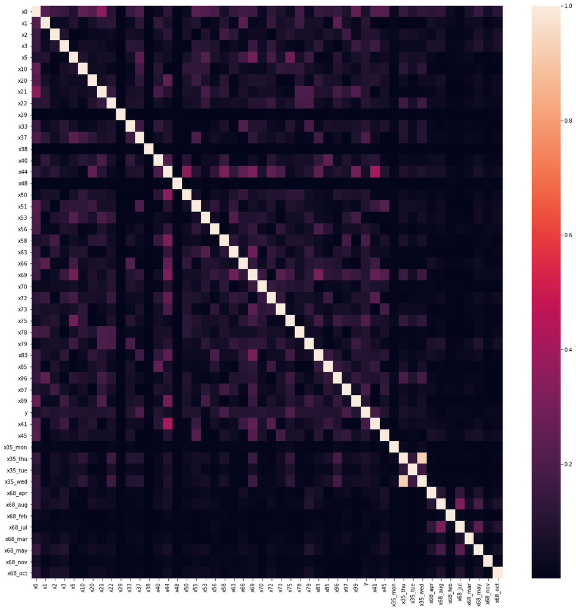

```python
# Creating correlation matrix
train_corr = abs(train_clean.corr())
# Mappting correlation matrix
f, ax = plt.subplots(figsize=(20, 20))
ax = sns.heatmap(train_corr)
```

It seems as though the only highly correlated features are `'x35_wed'` and `'x35_thu'`. These are the dummy variables we created above, so they are not simply representing the same data. However, from the value counts we calculated earlier, the wednesday and thursday categories combined account for over 96% of the data. If these two variables are indeed collinear, then they are representing a larger category that is highly skewed in the wed/thu bucket.

Because of this, we should eliminate the `'x35'` feature entirely so it does not throw off the results of the model.

```python
# Creating list of x35 categories to drop
dropcols = ['x35_mon','x35_tue','x35_wed','x35_thu']
train_clean = train_clean.drop(columns=dropcols)
```

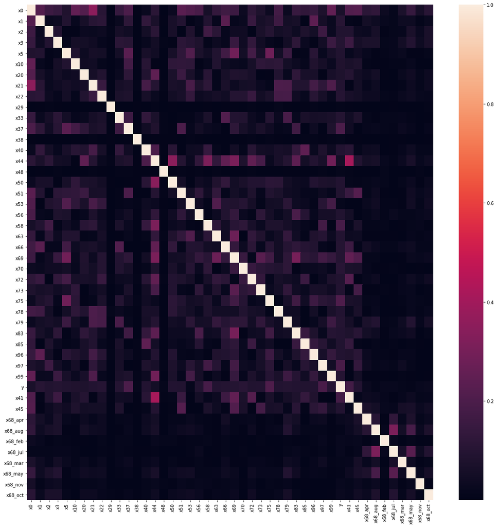

```python
# Recreating correlation matrix
train_corr = abs(train_clean.corr())
# Mappting correlation matrix
f, ax = plt.subplots(figsize=(20, 20))
ax = sns.heatmap(train_corr)
```

It now appears that collinearity has been eliminated and we have a reduced set of features.

## Recursive Feature Elimination

To help improve the model even further, I will use the scikit learn library's recursive feature elimination function to help narrow down the number of significant features for training. Since we are attempting to fit a binary classification model, I will implement this feature elimination using logistic regression with cross-fold validation.

```python
# Importing feature elimination
from sklearn.feature_selection import RFECV
from sklearn.linear_model import LogisticRegression
```

```python
# Creating feature and target sets
all_X = train_clean.drop(columns='y')
all_Y = train_clean['y']
```

```python
# Implementing a logistic regression model
lr = LogisticRegression(max_iter=1000)
# Creating a selector for feature elimination
selector = RFECV(lr, cv=10)
# Fitting the selector and model to trianing data
selector.fit(all_X, all_Y)
```

```
RFECV(cv=10,
      estimator=LogisticRegression(C=1.0, class_weight=None, dual=False,
                                   fit_intercept=True, intercept_scaling=1,
                                   l1_ratio=None, max_iter=1000,
                                   multi_class='auto', n_jobs=None,
                                   penalty='l2', random_state=None,
                                   solver='lbfgs', tol=0.0001, verbose=0,
                                   warm_start=False),
      min_features_to_select=1, n_jobs=None, scoring=None, step=1, verbose=0)
```

```python
# Checking for optimized columns
Optimized_columns=all_X.columns[selector.support_]
```

```python
print(Optimized_columns)
print(len(Optimized_columns))
```

```
Index(['x0', 'x1', 'x2', 'x3', 'x5', 'x10', 'x20', 'x21', 'x22', 'x29', 'x33',
       'x37', 'x38', 'x40', 'x44', 'x48', 'x50', 'x51', 'x53', 'x56', 'x58',
       'x63', 'x66', 'x69', 'x70', 'x72', 'x73', 'x75', 'x78', 'x79', 'x83',
       'x85', 'x96', 'x97', 'x99', 'x41', 'x45', 'x68_aug', 'x68_feb',
       'x68_mar', 'x68_nov', 'x68_oct'],
      dtype='object')
42
```

```python
# finding columns not selected
not_selected=[]
total_cols=list(all_X.columns)
for col in total_cols:
    if col in Optimized_columns:
        pass
    else:
        not_selected.append(col)
```

```python
not_selected
```

```
['x68_apr', 'x68_jul', 'x68_may']
```

```python
train_clean = train_clean.drop(columns=not_selected)
```

# Model Creation

## Error Metric

The error metric I will use for testing the models is provided in the assessment description. Models will be evaluated based on AUC score, so I will use this metric to evaluate the success of each model.

```python
# Importing auc metric
from sklearn.metrics import roc_auc_score

# Import Kfold
from sklearn.model_selection import KFold
```

## Logistic Regression

To begin the Machine Learning process, I will implement a basic logistic regression model, using the features that remain in the `'train_clean'` dataset. Logistic regression is a great place to start for a binary classifier, and will give us a baseline against which to test any other models for improvement.

First, I will define a function for the logistic regresssion model with K-fold cross validation.

```python
# Def a function for training/testing
def train_and_test(df, k=0):
    # Splitting dataframe from target column
    features = df.columns.drop('y')
    lr=LogisticRegression(max_iter=1000)

    # Building K-folds
    kf = KFold(n_splits=k, shuffle=True)
    auc_values = []
    for train_index, test_index, in kf.split(df):
        # Creating train/test set for fold
        train = df.iloc[train_index]
        test = df.iloc[test_index]
        # Fitting and predicting
        lr.fit(train[features], train['y'])
        predictions = lr.predict(test[features])
        # Calculate AUC
        auc = roc_auc_score(test['y'], predictions)
        auc_values.append(auc)
    # Averaging auc values
    avg_auc = np.mean(auc_values)
    var_auc = np.var(auc_values)
    print(avg_auc, var_auc)
    return avg_auc, var_auc
```

Next, I will train the model with a variety of K-fold values to see which provides the best accuracy.

```python
# Creating a list of k-fold values
splits = [2, 4, 6, 8, 10]

# Creating a dictionary of values for auc and var
auc_dict = {}

# Training a model with training data
for i in splits:
    k_auc, k_var = train_and_test(train, i)
    auc_dict[i] = k_auc, k_var
```

```
0.7864077223358682 1.445338211400935e-07
```

[output not shown]

```
0.7863791958247519 2.2179188732573277e-05
```

[output not shown]

```
0.784796173973918 5.206692782180382e-05
```

[output not shown]

[output cut: 9 more lines]

[output not shown]

```
0.7863007769084782 0.00011849641462344976
```

[output not shown]

[output cut: 17 more lines]

[output not shown]

```
0.7853201730657504 0.00011457379001719168
```

```python
auc_dict
```

```
{2: (0.7864077223358682, 1.445338211400935e-07),
 4: (0.7863791958247519, 2.2179188732573277e-05),
 6: (0.784796173973918, 5.206692782180382e-05),
 8: (0.7863007769084782, 0.00011849641462344976),
 10: (0.7853201730657504, 0.00011457379001719168)}
```

It appears as though the first iteration, with only 2 folds for cross validation, provided the highest AUC score and lowest variance in AUC scores.

## Balanced Class Adjustment

To establish a true baseline, however, I need to run this test again using a 'balanced' class model. Since the 1 y-values are disproportionate to the 0 values, this will help balance out the classes and hopefully improve the accuracy of our model.

```python
# Redefining train/test function for balanced class
def train_and_test(df, k=0):
    # Splitting dataframe from target column
    features = df.columns.drop('y')
    # Including balanced class
    lr=LogisticRegression(max_iter=1000, class_weight='balanced')

    # Building K-folds
    kf = KFold(n_splits=k, shuffle=True)
    auc_values = []
    for train_index, test_index, in kf.split(df):
        # Creating train/test set for fold
        train = df.iloc[train_index]
        test = df.iloc[test_index]
        # Fitting and predicting
        lr.fit(train[features], train['y'])
        predictions = lr.predict(test[features])
        # Calculate AUC
        auc = roc_auc_score(test['y'], predictions)
        auc_values.append(auc)
    # Averaging auc values
    avg_auc = np.mean(auc_values)
    var_auc = np.var(auc_values)
    print(avg_auc, var_auc)
    return avg_auc, var_auc
```

```python
# Re-running model with balanced classes
# Creating a list of k-fold values
splits = [2, 4, 6, 8, 10]

# Creating a dictionary of values for auc and var
auc_dict = {}

# Training a model with training data
for i in splits:
    k_auc, k_var = train_and_test(train, i)
    auc_dict[i] = k_auc, k_var
```

```
0.829410606406946 2.219268039043902e-11
```

[output not shown]

```
0.8284743020457778 1.9726083728891866e-05
```

[output not shown]

```
0.8295695189795288 1.3648832633338154e-05
```

[output not shown]

[output cut: 9 more lines]

[output not shown]

```
0.8293396643716002 3.137504571509923e-05
```

[output not shown]

[output cut: 17 more lines]

[output not shown]

```
0.8288388692373765 5.0362273750487695e-05
```

```python
auc_dict
```

```
{2: (0.829410606406946, 2.219268039043902e-11),
 4: (0.8284743020457778, 1.9726083728891866e-05),
 6: (0.8295695189795288, 1.3648832633338154e-05),
 8: (0.8293396643716002, 3.137504571509923e-05),
 10: (0.8288388692373765, 5.0362273750487695e-05)}
```

It now appears that our best model used 6 K-folds, returning the highest AUC score and still maintaining a low variance. This will be our threshold for improving model accuracy.

Next I will try a K Nearest Neighbors model.

## K Nearest Neighbors & Hyperparameter Tuning

K Nearest Neighbors is an effective tool for binary classification models. Here I will implement a basic model and include some hyperparameter tuning through a grid search. This will create several models and evaluate the best hyperparameters to use.

```python
# Importing K Nearest Neighbors model
from sklearn.neighbors import KNeighborsClassifier
# Importing Grid Search
from sklearn.model_selection import GridSearchCV
```

```python
# Creating features and target dataframes
all_X = train_clean.drop(columns='y')
all_Y = train_clean['y']
```

```python
# Dictionary of hyperparameters to test
hyperparameters = {
    "n_neighbors": range(1,20,2),
    "weights": ["distance", "uniform"],
    "algorithm": ['brute'],
    "p": [1,2]
}
# model selection
knn = KNeighborsClassifier()
# grid search cv (param=dictionary we created, cv=folds)
grid = GridSearchCV(knn,param_grid=hyperparameters,cv=10)

grid.fit(all_X, all_Y)

# returning best hyperparameters and score
best_params = grid.best_params_
best_score = grid.best_score_

# training using the best model
best_knn = grid.best_estimator_
```

```python
best_params
```

```
{'algorithm': 'brute', 'n_neighbors': 5, 'p': 2, 'weights': 'distance'}
```

```python
# Redefining train/test function for optimized knn model
def train_and_test_knn(df, k=0):
    # Splitting dataframe from target column
    features = df.columns.drop('y')
    # Including balanced class
    knn = KNeighborsClassifier(n_neighbors=5, weights='distance', algorithm=brute, p=2)

    # Building K-folds
    kf = KFold(n_splits=k, shuffle=True)
    auc_values = []
    for train_index, test_index, in kf.split(df):
        # Creating train/test set for fold
        train = df.iloc[train_index]
        test = df.iloc[test_index]
        # Fitting and predicting
        knn.fit(train[features], train['y'])
        predictions = knn.predict(test[features])
        # Calculate AUC
        auc = roc_auc_score(test['y'], predictions)
        auc_values.append(auc)
    # Averaging auc values
    avg_auc = np.mean(auc_values)
    var_auc = np.var(auc_values)
    print(avg_auc, var_auc)
    return avg_auc, var_auc
```

```python
# Running model for optimized knn
train_and_test(train_clean, k=10)
```

[output not shown]

```
0.814493114647189 5.168933046039276e-05
```

```
(0.814493114647189, 5.168933046039276e-05)
```

## Random Forest Classifier

The final basic model I will choose is a Random Forest Classifier. This algorithm is well suited to binary classification, and can eliminate the bias of a single decision tree.

I will use the same Grid Search optimization method to try and find the best hyperparameters for a Random Forest model.

```python
from sklearn.ensemble import RandomForestClassifier
```

```python
# Dictionary of hyperparameters to test
hyperparameters = {
    "n_estimators": range(100,500,100),
    "max_depth": [10],
    'class_weight':['balanced'],
    'n_jobs':[-1],
    'verbose':[1]
    }
# model selection
rf = RandomForestClassifier()
# grid search cv (param=dictionary we created, cv=folds)
grid = GridSearchCV(rf,param_grid=hyperparameters,cv=10)

grid.fit(all_X, all_Y)

# returning best hyperparameters and score
best_params = grid.best_params_
best_score = grid.best_score_

# training using the best model
best_rf = grid.best_estimator_
```

[output not shown]

[output cut: 249 more lines]

[output not shown]

```python
best_params
```

```
{'class_weight': 'balanced',
 'max_depth': 10,
 'n_estimators': 300,
 'n_jobs': -1,
 'verbose': 1}
```

```python
# Redefining train/test function for optimized random forest model
def train_and_test_rf(df, k=0):
    # Splitting dataframe from target column
    features = df.columns.drop('y')
    # Including balanced class
    rf = RandomForestClassifier(class_weight='balanced', max_depth=10, n_estimators=300, n_jobs=-1, verbose=1)

    # Building K-folds
    kf = KFold(n_splits=k, shuffle=True)
    auc_values = []
    for train_index, test_index, in kf.split(df):
        # Creating train/test set for fold
        train = df.iloc[train_index]
        test = df.iloc[test_index]
        # Fitting and predicting
        rf.fit(train[features], train['y'])
        predictions = rf.predict(test[features])
        # Calculate AUC
        auc = roc_auc_score(test['y'], predictions)
        auc_values.append(auc)
    # Averaging auc values
    avg_auc = np.mean(auc_values)
    var_auc = np.var(auc_values)
    print(avg_auc, var_auc)
    return avg_auc, var_auc
```

```python
# Running model for optimized rf
train_and_test_rf(train_clean, k=10)
```

[output not shown]

[output cut: 24 more lines]

[output not shown]

```
0.8653249605810925 0.00010615893586465878
```

```
[Parallel(n_jobs=4)]: Done 300 out of 300 | elapsed:    0.2s finished
```

```
(0.8653249605810925, 0.00010615893586465878)
```

## Random Forest Results

This algorithm produced an AOC score of 0.865, significantly higher than previous models. The variance has increased, but not enough to rule out this model as the most effective so far.

## Neural Network Application

Last, I will run two Neural Network models to see if the accuracy improves.

```python
# Importing Neural Network Classifier
from sklearn.neural_network import MLPClassifier
```

```python
# Redefining neural neetwork train and test function
def train_and_test_nn(df, k=0, n=0):
    # Splitting dataframe from target column
    features = df.columns.drop('y')
    # Including balanced class
    mlp = MLPClassifier(hidden_layer_sizes=(n,), max_iter=500)

    # Building K-folds
    kf = KFold(n_splits=k, shuffle=True)
    auc_values = []
    for train_index, test_index, in kf.split(df):
        # Creating train/test set for fold
        train = df.iloc[train_index]
        test = df.iloc[test_index]
        # Fitting and predicting
        mlp.fit(train[features], train['y'])
        predictions = mlp.predict(test[features])
        # Calculate AUC
        auc = roc_auc_score(test['y'], predictions)
        auc_values.append(auc)
    # Averaging auc values
    avg_auc = np.mean(auc_values)
    var_auc = np.var(auc_values)
    print(avg_auc, var_auc)
    return avg_auc, var_auc
```

```python
# Running model for different neuron levels in one hidden layer
neurons = [8, 16, 32]
accuracies = {}
for i in neurons:
    aoc_score, aoc_var = train_and_test_nn(train_clean, k=4, n=i)
    accuracies[i] = aoc_score, aoc_var
```

```
0.8333999923376425 0.0006858904796699593
0.8710044161766354 0.0003664845593469178
0.908420581924953 0.0005757786280987429
```

This increased the accuracty level significantly, but also increased the variance of the accuracy levels in the K-fold testing. This could mean the model is over-fitting, but the variance level is still very small compared to the overall accuracy level.

Finally, I will run a Neural Network model with two hidden layers, with 16 nodes each.

```python
# Redefining neural network for 2 hidden layers
def train_and_test_nn2(df, k=0, n=0):
    # Splitting dataframe from target column
    features = df.columns.drop('y')
    # Including balanced class
    mlp = MLPClassifier(hidden_layer_sizes=(n,n), max_iter=500)

    # Building K-folds
    kf = KFold(n_splits=k, shuffle=True)
    auc_values = []
    for train_index, test_index, in kf.split(df):
        # Creating train/test set for fold
        train = df.iloc[train_index]
        test = df.iloc[test_index]
        # Fitting and predicting
        mlp.fit(train[features], train['y'])
        predictions = mlp.predict(test[features])
        # Calculate AUC
        auc = roc_auc_score(test['y'], predictions)
        auc_values.append(auc)
    # Averaging auc values
    avg_auc = np.mean(auc_values)
    var_auc = np.var(auc_values)
    print(avg_auc, var_auc)
    return avg_auc, var_auc
```

```python
# Running model for different neuron levels in one hidden layer
neurons = [16]
accuracies = {}
for i in neurons:
    aoc_score, aoc_var = train_and_test_nn2(train_clean, k=4, n=i)
    accuracies[i] = aoc_score, aoc_var
```

```
0.90822683719581 1.79273849200885e-05
```

```python
# Running model for different neuron levels in two hidden layers
neurons = [32]
accuracies = {}
for i in neurons:
    aoc_score, aoc_var = train_and_test_nn2(train_clean, k=4, n=i)
    accuracies[i] = aoc_score, aoc_var
```

```
0.9302986826327426 1.603054636250812e-05
```

This model looks to be the best overall, with the highest AOC and one of the lowest variances of the models we have generated.

# Generating Predictions

Based on this testing, it seems the two best fitting models are:

- Neural Network Classifier (AOC: 0.9303) **Hyper-parameters: 2 hidden layers, 32 nodes each** K-fold validation: 4 folds
- Random Forest Classifier (AOC: 0.8653) **Hyper-parameters: class_weight: 'balanced', max_depth: 10, n_estimators: 300, n_jobs: -1** K-fold validation: 10 folds

Now I will use these models to generate predictions for the test data and save those predictions in the appropriate format as per the assessment instructions.

## Test Data Cleaning

First, I need to clean the test data with the same process used above.

```python
# Reimporting test data to clean dataframe
test = pd.read_csv('testdata.csv')
```

```python
# Identifying text columns
text_vals = test.select_dtypes(include=['object'])
text_vals.head()
# Cleaning the values of x41 and x45, storing as float
text_vals['x41'] = text_vals['x41'].str.replace('$','').astype('float')
text_vals['x45'] = text_vals['x45'].str.replace('%','').astype('float')
```

```python
# Creating a mapping dictionary for correct labeling
dict = {'volkswagon': 'volkswagen', 'Toyota':'toyota',
       'bmw':'bmw', 'Honda':'honda', 'tesla':'tesla',
        'chrystler':'chrysler', 'nissan':'nissan',
        'ford':'ford','mercades':'mercedes',
       'chevrolet':'chevrolet'}
# Replacing values using dictionary
text_vals['x34'] = text_vals['x34'].replace(dict)

# Creating mapping dictionary
dict2 = {'July':'jul','Jun':'jun',
       'Aug':'aug','May':'may',
       'sept.':'sep','Apr':'apr',
       'Oct':'oct','Mar':'mar',
       'Nov':'nov','Feb':'feb',
       'Dev':'dec','January':'jan'}
# Replacing values using dictionary
text_vals['x68'] = text_vals['x68'].replace(dict2)
```

```python
# Drop x93 from text vals dataframe
text_vals = text_vals.drop(columns='x93')
```

```python
text_vals.head()
```

|  | x34 | x35 | x41 | x45 | x68 |
| --- | --- | --- | --- | --- | --- |
| 0 | bmw | thurday | 107.93 | 0.00 | jun |
| 1 | tesla | thurday | -600.43 | 0.02 | may |
| 2 | honda | thurday | 103.08 | -0.00 | jun |
| 3 | volkswagen | thurday | 1518.78 | -0.01 | sep |
| 4 | volkswagen | thurday | -2324.39 | -0.00 | jun |

```python
# Selecting only text columns
textcols = ['x34','x35','x68']
# Get dummy prefix names
prefixes = list(text_vals[textcols].columns)
# Getting dummy features for each text column
text_dummies = pd.get_dummies(text_vals, prefix=prefixes)
```

```python
# Dropping dirty text columns from original dataset
dropcols = ['x34','x35','x41','x45','x68','x93']
test = test.drop(columns=dropcols)
```

```python
# Reintroducing our cleaned data into the original dataset
test = pd.concat([test,text_dummies], axis=1)
```

```python
# Filling null values with mean for feature
test.fillna(value=0, inplace=True)
```

```python
test.info(verbose=True)
```

```
<class 'pandas.core.frame.DataFrame'>
RangeIndex: 10000 entries, 0 to 9999
Data columns (total 126 columns):
x0                float64
x1                float64
x2                float64
x3                float64
x4                float64
x5                float64
x6                float64
x7                float64
x8                float64
x9                float64
x10               float64
x11               float64
x12               float64
x13               float64
x14               float64
x15               float64
x16               float64
x17               float64
x18               float64
x19               float64
x20               float64
x21               float64
x22               float64
x23               float64
x24               float64
x25               float64
x26               float64
x27               float64
x28               float64
x29               float64
x30               float64
x31               float64
x32               float64
x33               float64
x36               float64
x37               float64
x38               float64
```

[output cut: 76 more lines]

```
x35_wednesday     uint8
x68_apr           uint8
x68_aug           uint8
x68_dec           uint8
x68_feb           uint8
x68_jan           uint8
x68_jul           uint8
x68_jun           uint8
x68_mar           uint8
x68_may           uint8
x68_nov           uint8
x68_oct           uint8
x68_sep           uint8
dtypes: float64(96), uint8(30)
memory usage: 7.6 MB
```

```python
# Saving column names for future dataframe
colnames = test.columns
# Creating minmax scaler instance
mm_scaler = preprocessing.MinMaxScaler()
# Transforming data into scaled array
df_mm = mm_scaler.fit_transform(test)
# Creating new dataframe with scaled data
test_clean = pd.DataFrame(df_mm, columns=colnames)
```

```python
# Matching column names from training dataset
train_cols = train_clean.drop(columns='y')
keepcols = train_cols.columns
test_clean = test_clean[keepcols]
```

## Predicting with Random Forest Classifier

```python
features = train_clean.drop(columns='y')

# Running Model on training data
rf = RandomForestClassifier(class_weight='balanced', max_depth=10, n_estimators=300, n_jobs=-1, verbose=1)
rf.fit(features, train_clean['y'])
predictions = rf.predict_proba(test_clean)
```

[output not shown]

```python
# Saving 1 predictions to dataframe
rf_predictions = pd.DataFrame(predictions[:,1])
```

```python
# Saving Random Forest predictions to file
rf_predictions.to_csv('RFPredictions_EKirkland.csv')
```

## Predicting with Neural Network Classifier

```python
features = train_clean.drop(columns='y')

# Running Model on training data
mlp = MLPClassifier(hidden_layer_sizes=(32,32), max_iter=500)
mlp.fit(features, train_clean['y'])
predictions = mlp.predict_proba(test_clean)
```

```python
# Saving 1 predictions to dataframe
nn_predictions = pd.DataFrame(predictions[:,1])
# Saving Neural Network predictions to file
nn_predictions.to_csv('NNPredictions_EKirkland.csv')
```